# Automative Reporting Weedmon

## Download necessary packages if not downloaded

*Note install/if not use code below*

install.packages(c(“tidyverse”, “readxl”, “here”, “dplyr”, “ggplot2”, “ggrepel”, “DT”, “knitr”))

devtools::install_github(“haozhu233/kableExtra”)

# SET YEAR

Set Working Directory *Occasionally on Windows R Markdown has trouble finding directory, specified full file path location in read_excel file can use setwd() if working*

# File Notes

Files that do change ACCESS: qry_2020_DRT_CountOfNNIS_perTransect2.xlsx SAMO’s 25 Target Invasive Species.xlsx

ARCGIS: raw_POE_WeedSurveyLn_2016to2020.xlsx raw_POE_WeedSurveyLn_2016to2020.xlsx

Files that Don’t change year to year POE_WeedSurveyLn&Pt_2016to2020.xlsx

# Format excel sheets and clean

Making the clean excel files

Making POE Location Key for table A-1 *Need to locate clean sheet from 2016-2020 only used for POE names*

# Make Clean SPP record for POE

# Create Species Key from 2 letter/3 letter/ full name

# Notes

MEDN_Zone: Zone 1 = 1 Zone 2 = 2 Both = 3

when doing species combine to only have unique species no duplicates

POE Name = LOC_NM if doesn’t have name then remove

Do for point Buffer_rev = default distance is .01 replace all .01 with .5 Anything less then .25 make .5

if/then statement for zone 1, zone 2 or both

Point zone 1 or zone 2 area = pi*buffer^2 Line Buffer Distance in Meters* Length_m(Ln) * Buffer multiplier

For Length_m(Ln) combine st_length_ and Shape__L_3 make 0 = NA 10^5 power for st_length Shape__L_2 is the correct value

Buffer multiplier = BUFFDIR FULL = 2 LEFT or RIGHT = 1

Buffer Distance in Meters = BUFFER_M

# Results

### Table 3 in report

|  | Species | nsites_poe | nsites_drt | tot_sites | pct_poe | pct_drt | tot_pct |
| --- | --- | --- | --- | --- | --- | --- | --- |
| 1 | CARPYC | 17 | 30 | 47 | 12.69 | 9.09 | 21.78 |
| 2 | CENSOL | 2 | 5 | 7 | 1.49 | 1.52 | 3.01 |
| 3 | CIRVUL | 6 | 6 | 12 | 4.48 | 1.82 | 6.3 |
| 4 | CYPINV | 6 | 1 | 7 | 4.48 | 0.3 | 4.78 |
| 5 | EUPTER | 8 | 5 | 13 | 5.97 | 1.52 | 7.49 |
| 6 | FOEVUL | 12 | 13 | 25 | 8.96 | 3.94 | 12.9 |
| 7 | LEPLAT | 5 | 1 | 6 | 3.73 | 0.3 | 4.03 |
| 8 | NICGLA | 14 | 7 | 21 | 10.45 | 2.12 | 12.57 |
| 9 | PENSET | 6 | 2 | 8 | 4.48 | 0.61 | 5.09 |
| 10 | PHAAQU | 4 | 8 | 12 | 2.99 | 2.42 | 5.41 |

[output cut: 11 more lines]

## Points of Entry

### Table A-1: group by location, scientific name, zone, area for each species per site

*Need to locate clean sheet from 2016-2020 for POE names*

|  | POE# | Location | Gross Area Infested (sq. m) | Zone |
| --- | --- | --- | --- | --- |
| 1 | POE-046 | Gillette Ranch | 1340156.55220532 | Buffer |
| 2 | POE-032 | Santa Ynez Cyn Park Trailhead | 442327.2 | Buffer |
| 3 | POE-046 | Gillette Ranch | 3.14159265358979 | Buffer |
| 4 | POE-034 | Arroyo Sequit | 0.785398163397448 | Buffer |
| 5 | POE-037 | Charmlee Regional Park / Charmlee Natural Area | 3.92699081698724 | Buffer |
| 6 | POE-038 | Las Virgenes View Trail Trailhead | 301202.52819449 | Buffer |
| 7 | POE-043 | BBT - Topanga State Park Main Entrance | 9667237.91017612 | Buffer |
| 8 | POE-045 | BBT - Kanan Dume Rd N - overflow | 0.785398163397448 | Buffer |
| 9 | POE-046 | Gillette Ranch | 23465299.0539816 | Buffer |
| 10 | POE-048 | Temescal Gateway Park | 897218.8 | Buffer |

[output cut: 241 more lines]

### Table A-2 part 1 (a)

N sites surveyed, N of NIS Observed, N Sites w/NIS observed, N sites w/ NIS, N Sites w/o NIS, % Sites w/ NIS, % of Species Detected, Area Infestation = total area

|  | N_sites_Surveyed | N_of_NIS_Observed | Sites_w_NIS | Sites_wo_NIS | per_Sites_w_NIS | per_of_Species_Detected | Area_of_Infestation |
| --- | --- | --- | --- | --- | --- | --- | --- |
| 1 | 34 | 24 | 29 | 5 | 85.29 | 96 | 3003415385.78061 |

### Species total area per year named table A-2 part 2 (b)

|  | Park | Species | Area Infestation [sq. m.] |
| --- | --- | --- | --- |
| 1 | SAMO | Ailanthus altissima | 1340157 |
| 2 | SAMO | Arundo donax | 442330 |
| 3 | SAMO | Carduus pycnocephalus | 343515840 |
| 4 | SAMO | Centaurea solstitialis | 1689067 |
| 5 | SAMO | Cirsium vulgare | 25252273 |
| 6 | SAMO | Conium maculatum | 1 |
| 7 | SAMO | Cortaderia selloana | 3622469 |
| 8 | SAMO | Cyperus involucratus | 46190129 |
| 9 | SAMO | Delairea odorata | 213455583 |
| 10 | SAMO | Euphorbia terracina | 422712659 |

[output cut: 15 more lines]

### Most common target species at POEs and how many sites was it seen at

```
## # A tibble: 1 x 3
##   Scientific_name   spp       n
##   <chr>             <chr> <int>
## 1 Salsola australis SAAU3    21
```

### Out of the total number of sites how many had 1-5 and 6 or more

```
##   Numspp_one_to_five Numspp_six_or_more
## 1                 25                  9
```

### Which location had the highest number of target invasives present and how many

*multiple returns if multiple sites with max value*

```
## # A tibble: 2 x 3
##   POE     spp_at_site Location
##   <chr>         <int> <chr>
## 1 POE-048          12 Temescal Gateway Park
## 2 POE-062          12 Malibu Ck St Pk/Tapia Park (Malibu Creek State Park)
```

### Pie chart Figrue 4

Count of POEs with Different Number Classes of Target Invasive Species Detected

[output not shown]

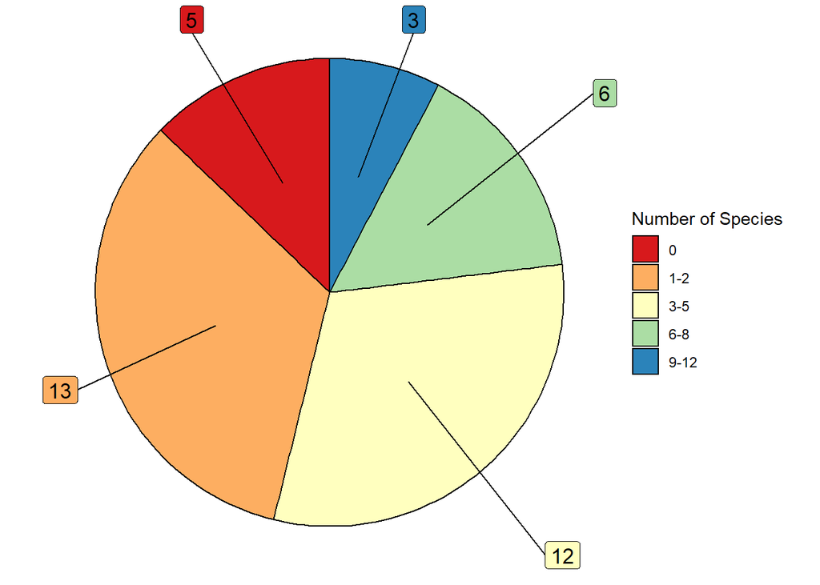

### Bar Chart Figure 4 ALT

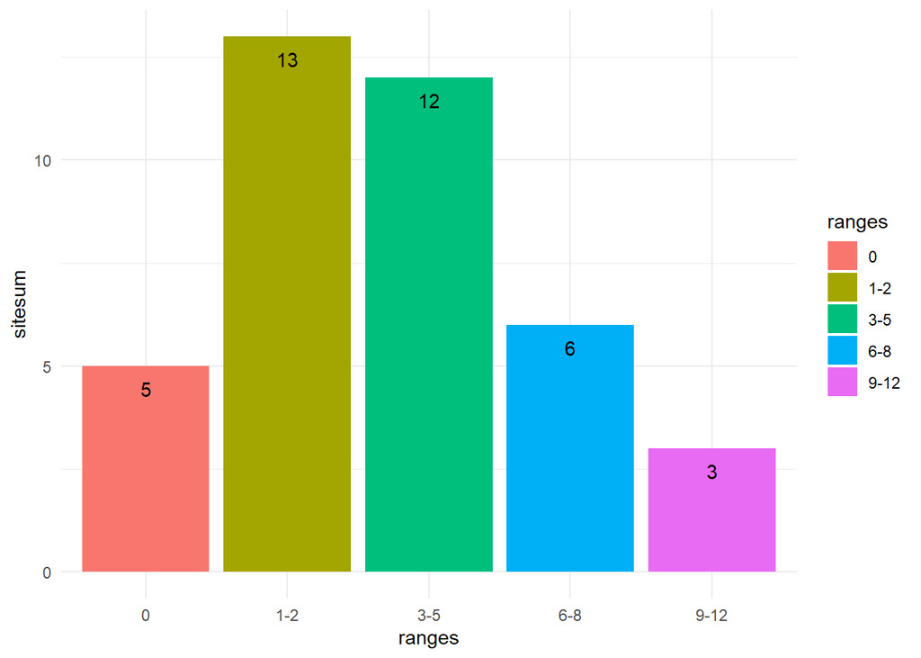

## Dirt Roads and Trails

### Make new dataframe to have how many times a number of species occurred at each site in DRT

```
##   numspp numsites
## 1      1       23
## 2      2       20
## 3      3       10
## 4      4        6
## 5      5        1
## 6      0      208
```

### Pie chart Figure 5

Count of DRTs with different numbers of Target Species detected * include numbers in each slide of pie *

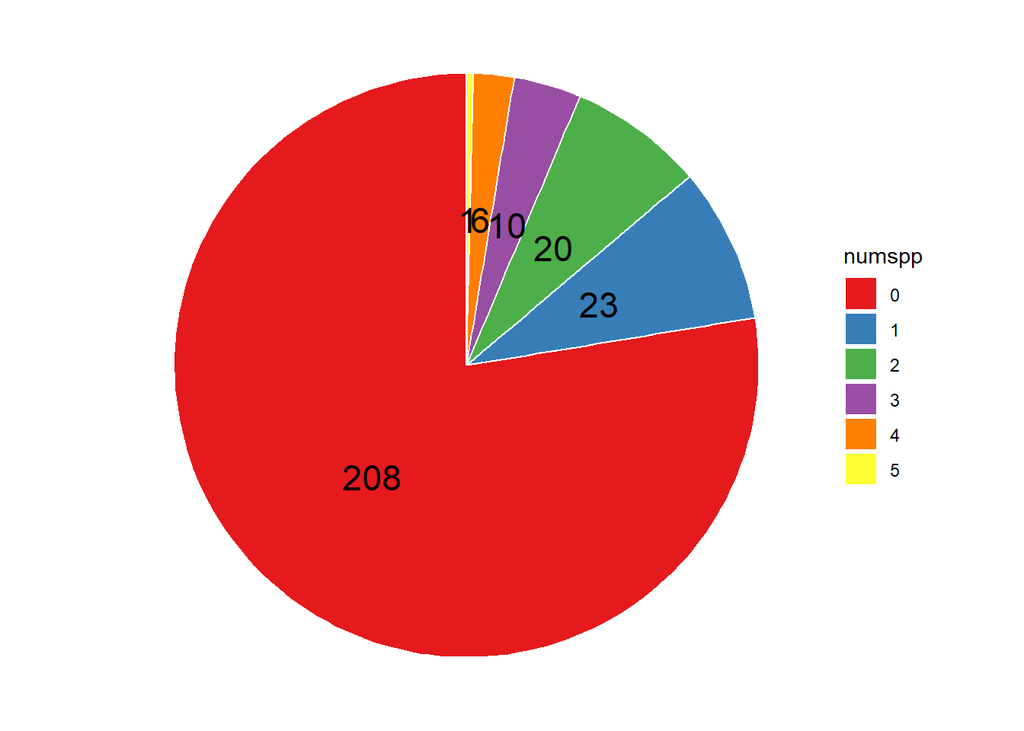

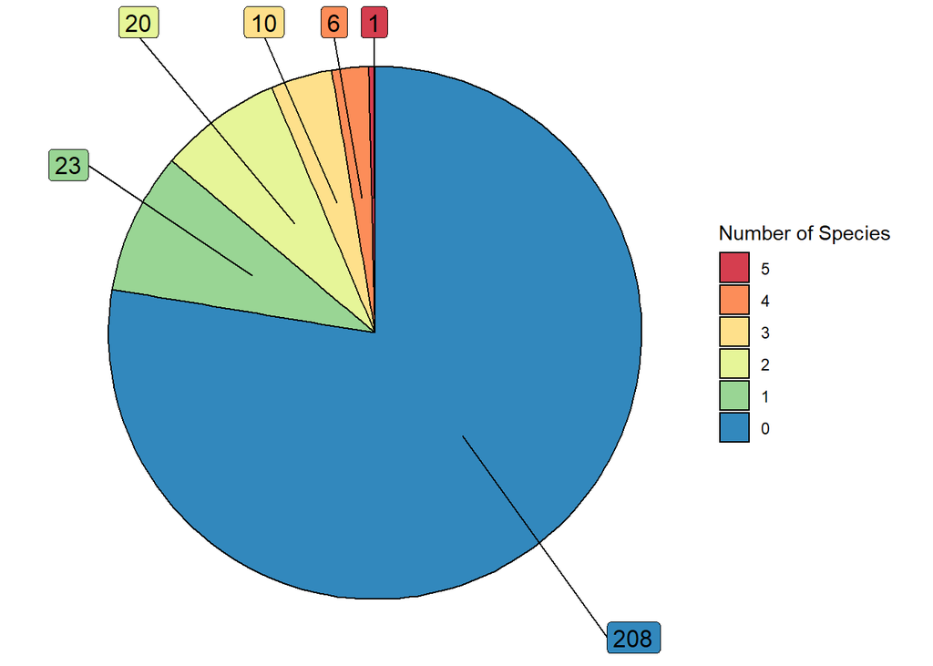

# Barchart DRT Figure 5 ALT

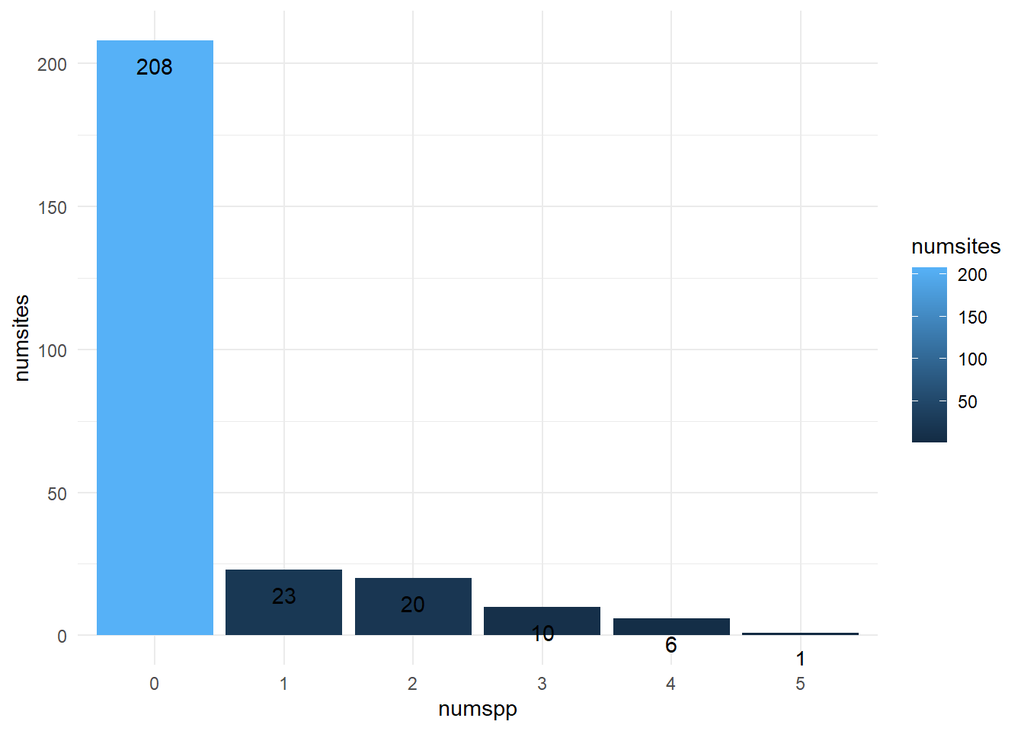

# Table B-2

|  | DRT | Location | Species Code | X0 | X1 | X2 | X3 | X4 | X5 | X6 | X7 | X8 | X9 | X10 |
| --- | --- | --- | --- | --- | --- | --- | --- | --- | --- | --- | --- | --- | --- | --- |
| 1 | DRT-001 |  | NONE | X |  |  |  |  |  |  |  |  |  |  |
| 2 | DRT-004 |  | NONE | X |  |  |  |  |  |  |  |  |  |  |
| 3 | DRT-005 |  | NONE | X |  |  |  |  |  |  |  |  |  |  |
| 4 | DRT-006 |  | NONE | X |  |  |  |  |  |  |  |  |  |  |
| 5 | DRT-008 |  | NONE | X |  |  |  |  |  |  |  |  |  |  |
| 6 | DRT-009 |  | NONE | X |  |  |  |  |  |  |  |  |  |  |
| 7 | DRT-011 |  | NONE | X |  |  |  |  |  |  |  |  |  |  |
| 8 | DRT-012 |  | NONE | X |  |  |  |  |  |  |  |  |  |  |
| 9 | DRT-013 |  | NONE | X |  |  |  |  |  |  |  |  |  |  |
| 10 | DRT-016 |  | NONE | X |  |  |  |  |  |  |  |  |  |  |

[output cut: 320 more lines]

### Total Sites visited this year

```
## [1] 268
```

### How many of the total target species were found on DRTs

```
## [1] 15
```

```
## [1] 60
```

### how many had one and two species found at site

```
## [1] 43
```

### Most common target invasive and at how many sites

[output not shown]

# Extras and possible future questions

### Greatest number of sites for any one non-native species

### Number of points of contact for vegmon (%cover)

One point of contact = 1% so # of hits is the % cover for that plot

### Calculating Percent Cover by Rows Potential VegMon

Not necessary but may be useful for vegmon code